# EasyVisa Project: Visa Approval Prediction

### Problem Definition

The Immigration and Nationality Act (INA) of the US permits foreign workers to come to the United States to work on either a temporary or permanent basis. The process of reviewing every case is becoming a tedious task as the number of applicants is increasing every year.

The objective is to develop a Machine Learning based solution that can help the Office of Foreign Labor Certification (OFLC) in shortlisting the candidates having higher chances of VISA approval. As a data scientist at EasyVisa, the goal is to:

1. Facilitate the process of visa approvals.
2. Recommend a suitable profile for the applicants for whom the visa should be certified or denied based on the drivers that significantly influence the case status.

```python
# !pip install pandas numpy matplotlib seaborn scikit-learn xgboost imbalanced-learn notebook
```

```python
import pandas as pd
import numpy as np
import matplotlib.pyplot as plt
import seaborn as sns
from sklearn.model_selection import train_test_split, GridSearchCV
from sklearn.metrics import confusion_matrix, classification_report, f1_score, accuracy_score, recall_score, precision_score, make_scorer
from sklearn import metrics
from sklearn.tree import DecisionTreeClassifier
from sklearn.ensemble import RandomForestClassifier, BaggingClassifier, AdaBoostClassifier, GradientBoostingClassifier, StackingClassifier
from xgboost import XGBClassifier
from imblearn.over_sampling import SMOTE
from imblearn.under_sampling import RandomUnderSampler

# Set visual style
sns.set_theme(style="whitegrid")
plt.rcParams['figure.figsize'] = [12, 8]

# Load the dataset
data = pd.read_csv('EasyVisa.csv')

# Display the first few rows
data.head()
```

|  | case_id | continent | education_of_employee | has_job_experience | requires_job_training | no_of_employees | yr_of_estab | region_of_employment | prevailing_wage | unit_of_wage | full_time_position | case_status |
| --- | --- | --- | --- | --- | --- | --- | --- | --- | --- | --- | --- | --- |
| 0 | EZYV01 | Asia | High School | N | N | 14513 | 2007 | West | 592.2029 | Hour | Y | Denied |
| 1 | EZYV02 | Asia | Master's | Y | N | 2412 | 2002 | Northeast | 83425.6500 | Year | Y | Certified |
| 2 | EZYV03 | Asia | Bachelor's | N | Y | 44444 | 2008 | West | 122996.8600 | Year | Y | Denied |
| 3 | EZYV04 | Asia | Bachelor's | N | N | 98 | 1897 | West | 83434.0300 | Year | Y | Denied |
| 4 | EZYV05 | Africa | Master's | Y | N | 1082 | 2005 | South | 149907.3900 | Year | Y | Certified |

```python
data.info()
```

```
<class 'pandas.DataFrame'>
RangeIndex: 25480 entries, 0 to 25479
Data columns (total 12 columns):
 #   Column                 Non-Null Count  Dtype
---  ------                 --------------  -----
 0   case_id                25480 non-null  str
 1   continent              25480 non-null  str
 2   education_of_employee  25480 non-null  str
 3   has_job_experience     25480 non-null  str
 4   requires_job_training  25480 non-null  str
 5   no_of_employees        25480 non-null  int64
 6   yr_of_estab            25480 non-null  int64
 7   region_of_employment   25480 non-null  str
 8   prevailing_wage        25480 non-null  float64
 9   unit_of_wage           25480 non-null  str
 10  full_time_position     25480 non-null  str
 11  case_status            25480 non-null  str
dtypes: float64(1), int64(2), str(9)
memory usage: 2.3 MB
```

```python
data.isna().sum()
```

```
case_id                  0
continent                0
education_of_employee    0
has_job_experience       0
requires_job_training    0
no_of_employees          0
yr_of_estab              0
region_of_employment     0
prevailing_wage          0
unit_of_wage             0
full_time_position       0
case_status              0
dtype: int64
```

```python
data.duplicated().sum()
```

```
np.int64(0)
```

```python
data.nunique()
```

```
case_id                  25480
continent                    6
education_of_employee        4
has_job_experience           2
requires_job_training        2
no_of_employees           7105
yr_of_estab                199
region_of_employment         5
prevailing_wage          25454
unit_of_wage                 4
full_time_position           2
case_status                  2
dtype: int64
```

```python
data.describe().T
```

|  | count | mean | std | min | 25% | 50% | 75% | max |
| --- | --- | --- | --- | --- | --- | --- | --- | --- |
| no_of_employees | 25480.0 | 5667.043210 | 22877.928848 | -26.0000 | 1022.00 | 2109.00 | 3504.0000 | 602069.00 |
| yr_of_estab | 25480.0 | 1979.409929 | 42.366929 | 1800.0000 | 1976.00 | 1997.00 | 2005.0000 | 2016.00 |
| prevailing_wage | 25480.0 | 74455.814592 | 52815.942327 | 2.1367 | 34015.48 | 70308.21 | 107735.5125 | 319210.27 |

```python
# Function to compute performance metrics
def model_performance_classification(model, predictors, target):
    """
    Function to compute different metrics to check classification model performance
    """
    pred = model.predict(predictors)
    acc = accuracy_score(target, pred)
    recall = recall_score(target, pred)
    precision = precision_score(target, pred)
    f1 = f1_score(target, pred)

    df_perf = pd.DataFrame(
        {"Accuracy": acc, "Recall": recall, "Precision": precision, "F1": f1},
        index=[0],
    )
    return df_perf

def confusion_matrix_plot(model, predictors, target):
    """
    To plot the confusion_matrix with percentages
    """
    y_pred = model.predict(predictors)
    cm = confusion_matrix(target, y_pred)
    labels = np.asarray(
        [["{0:0.0f}".format(item), "{0:.2%}".format(item / cm.flatten().sum())] for item in cm.flatten()]
    ).reshape(2, 2, 2)

    label_map = np.array(["True Neg", "False Pos", "False Neg", "True Pos"]).reshape(2, 2)
    annot = np.array(
        ["{}\n{}\n{}".format(l1, l2, l3) for l1, l2, l3 in zip(label_map.flatten(), labels[:, :, 0].flatten(), labels[:, :, 1].flatten())]
    ).reshape(2, 2)

    plt.figure(figsize=(8, 5))
    sns.heatmap(cm, annot=annot, fmt="", cbar=False)
    plt.ylabel("True label")
    plt.xlabel("Predicted label")
    plt.show()

def plot_feature_importance(model, predictors):
    """
    To plot the feature importance of a model
    """
    importances = model.feature_importances_
    indices = np.argsort(importances)
    feature_names = predictors.columns

    plt.figure(figsize=(12, 12))
    plt.title('Feature Importances')
    plt.barh(range(len(indices)), importances[indices], color='violet', align='center')
    plt.yticks(range(len(indices)), [feature_names[i] for i in indices])
    plt.xlabel('Relative Importance')
    plt.show()
```

## 1. Exploratory Data Analysis (EDA) - Granular Analysis

```python
def histogram_boxplot(data, feature, figsize=(15, 10), kde=False, bins=None):
    """
    Boxplot and histogram combined

    data: dataframe
    feature: dataframe column
    figsize: size of figure (default (15,10))
    kde: whether to show the density curve (default False)
    bins: number of bins for histogram (default None)
    """
    f2, (ax_box2, ax_hist2) = plt.subplots(
        nrows=2,  # Number of rows of the subplot grid= 2
        sharex=True,  # x-axis will be shared among all subplots
        gridspec_kw={"height_ratios": (0.25, 0.75)},
        figsize=figsize,
    )  # creating the 2 subplots
    sns.boxplot(
        data=data, x=feature, ax=ax_box2, showmeans=True, color="violet"
    )  # boxplot will be created and a triangle will indicate the mean value of the column
    sns.histplot(
        data=data, x=feature, kde=kde, ax=ax_hist2, bins=bins
    ) if bins else sns.histplot(
        data=data, x=feature, kde=kde, ax=ax_hist2
    )  # For histogram
    ax_hist2.axvline(
        data[feature].mean(), color="green", linestyle="--"
    )  # Add mean to the histogram
    ax_hist2.axvline(
        data[feature].median(), color="black", linestyle="-"
    )  # Add median to the histogram
```

```python
# function to create labeled barplots


def labeled_barplot(data, feature, perc=False, n=None):
    """
    Barplot with percentage at the top

    data: dataframe
    feature: dataframe column
    perc: whether to display percentages instead of count (default is False)
    n: displays the top n category levels (default is None, i.e., display all levels)
    """

    total = len(data[feature])  # length of the column
    count = data[feature].nunique()
    if n is None:
        plt.figure(figsize=(count + 2, 6))
    else:
        plt.figure(figsize=(n + 2, 6))

    plt.xticks(rotation=90, fontsize=15)
    ax = sns.countplot(
        data=data,
        x=feature,
        palette="Paired",
        order=data[feature].value_counts().index[:n],
    )

    for p in ax.patches:
        if perc == True:
            label = "{:.1f}%".format(
                100 * p.get_height() / total
            )  # percentage of each class of the category
        else:
            label = p.get_height()  # count of each level of the category

        x = p.get_x() + p.get_width() / 2  # width of the plot
        y = p.get_height()  # height of the plot

        ax.annotate(
            label,
            (x, y),
            ha="center",
            va="center",
            size=12,
            xytext=(0, 5),
            textcoords="offset points",
        )  # annotate the percentage

    plt.show()  # show the plot
```

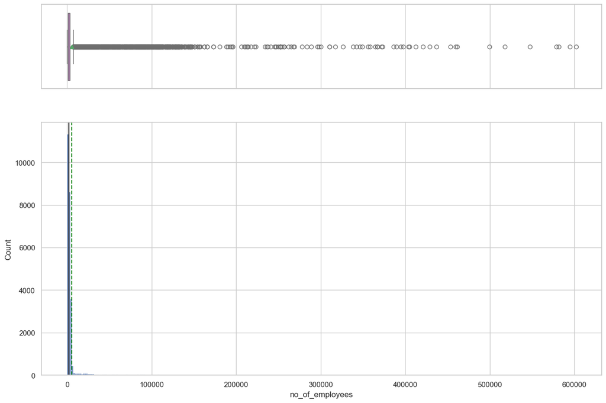

```python
histogram_boxplot(data, 'no_of_employees')
```

### Observations on no_of_employees:

- The distribution is heavily right-skewed with significant outliers on the upper end.

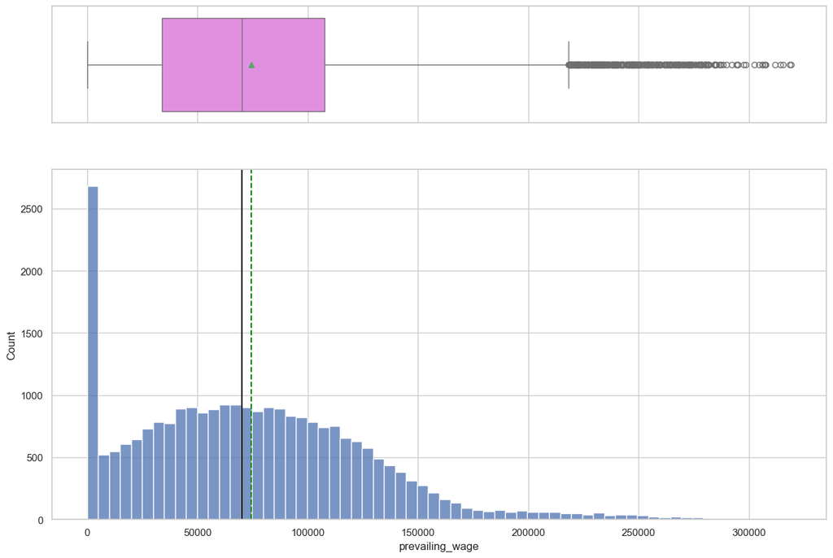

```python
histogram_boxplot(data, 'prevailing_wage')
```

### Observations on prevailing_wage:

- Right-skewed distribution with multiple peaks, suggesting the need for wage unit normalization.

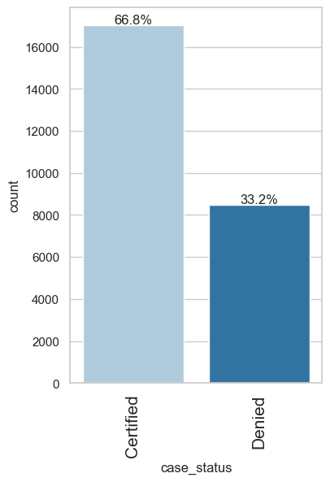

```python
labeled_barplot(data,'case_status',perc=True)
```

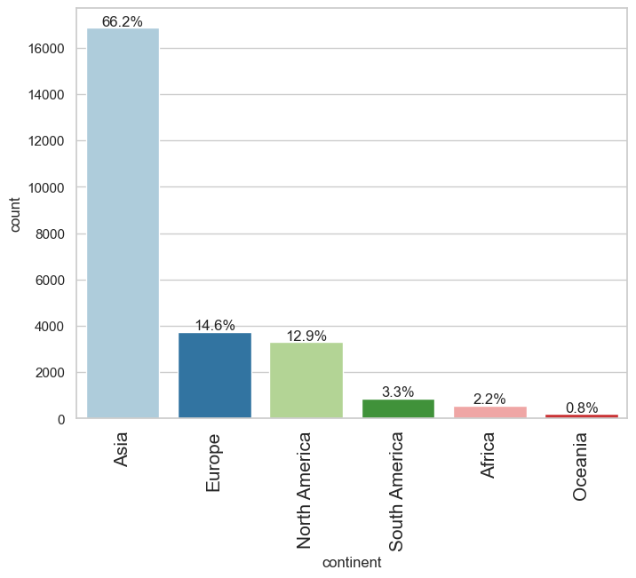

```python
labeled_barplot(data,'continent',perc=True)
```

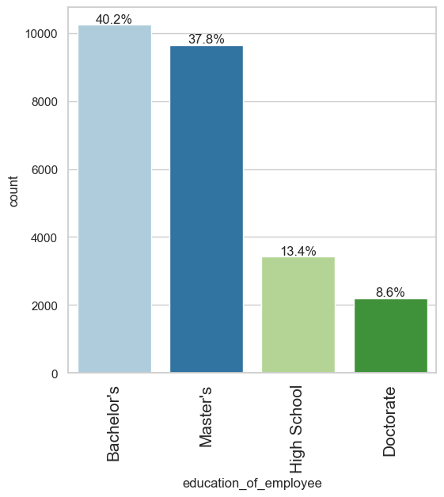

```python
labeled_barplot(data,'education_of_employee',perc=True)
```

### Bivariate analysis

**Correlation Check**

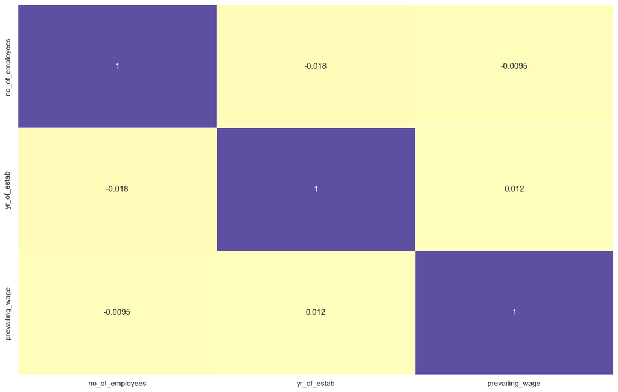

```python
sns.set(rc={'figure.figsize':(16,10)})
sns.heatmap(data.corr(numeric_only = True),
            annot=True,
            linewidths=.5,
            center=0,
            cbar=False,
            cmap="Spectral")
plt.show()
```

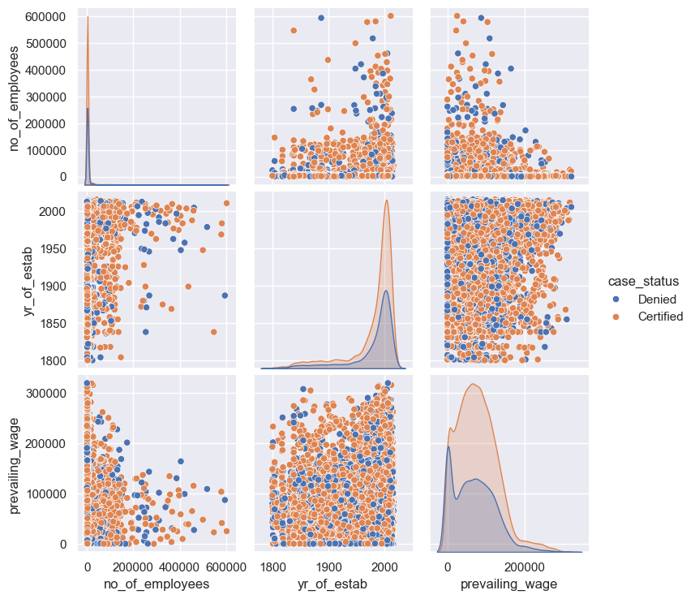

```python
sns.pairplot(data=data,hue="case_status")
plt.show()
```

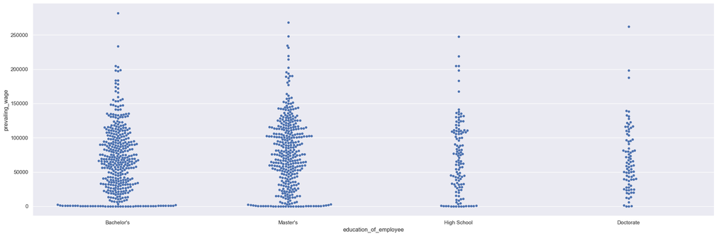

```python
sns.catplot(x="education_of_employee", y="prevailing_wage", kind="swarm", data=data.sample(1000, random_state=1), height=7, aspect=3);
```

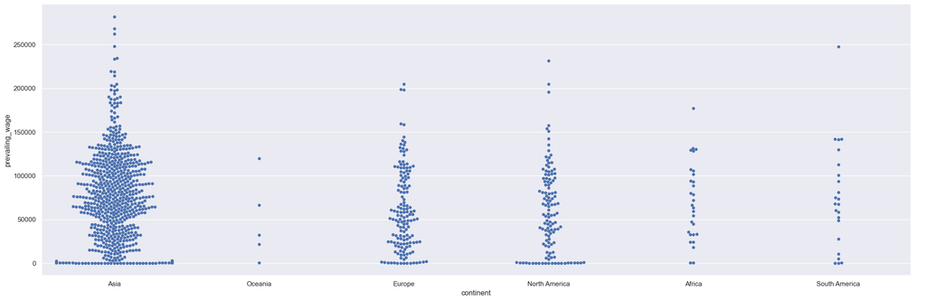

```python
sns.catplot(x="continent", y="prevailing_wage", kind="swarm",
            data=data.sample(1000, random_state=1), height=7, aspect=3);
```

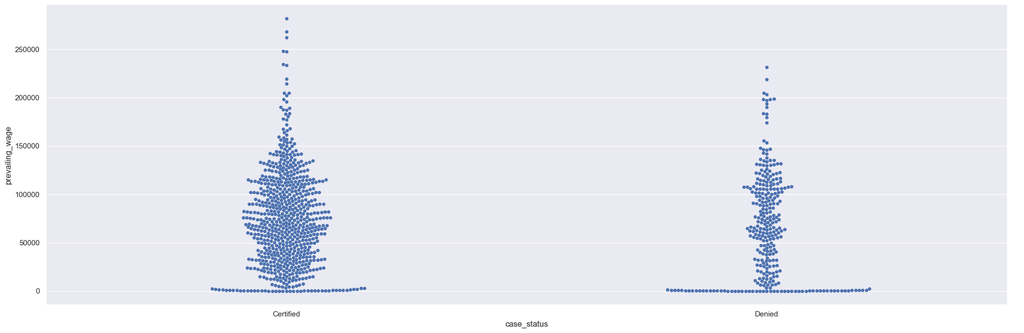

```python
sns.catplot(x="case_status", y="prevailing_wage", kind="swarm",
            data=data.sample(1000, random_state=1), height=7, aspect=3);
```

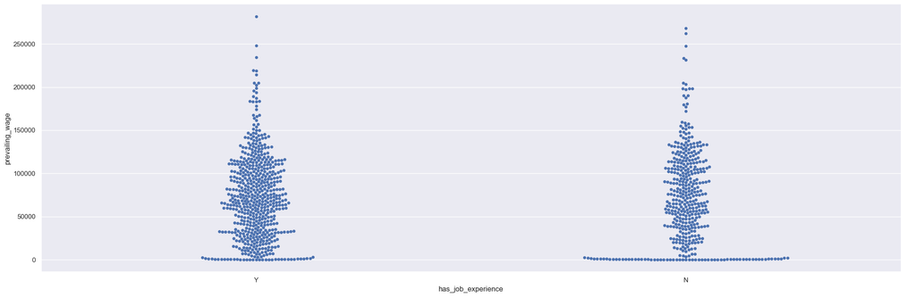

```python
sns.catplot(x="has_job_experience", y="prevailing_wage", kind="swarm",
            data=data.sample(1000, random_state=1), height=7, aspect=3);
```